# Ejercicio práctico DeAcero

En este archivo presento mis resultados y respuestas a las preguntas indicadas.

```python
import matplotlib.pyplot as plt
import seaborn as sns; sns.set_style('whitegrid')
import numpy as np
import pandas as pd
from sklearn import preprocessing

from sklearn.ensemble import RandomForestClassifier
from sklearn.preprocessing import MinMaxScaler
from sklearn.model_selection import train_test_split

import json

np.random.seed(0)
np.set_printoptions(suppress=True)
```

## Dataset

```python
data = pd.read_csv('Hotel.csv', index_col=0, parse_dates=['reservation_status_date'])
print(len(data))
data
```

```
119390
```

| id | hotel | is_canceled | lead_time | arrival_date_year | arrival_date_month | arrival_date_week_number | arrival_date_day_of_month | stays_in_weekend_nights | stays_in_week_nights | adults | ... | deposit_type | agent | company | days_in_waiting_list | customer_type | adr | required_car_parking_spaces | total_of_special_requests | reservation_status | reservation_status_date |
| --- | --- | --- | --- | --- | --- | --- | --- | --- | --- | --- | --- | --- | --- | --- | --- | --- | --- | --- | --- | --- | --- |
| 1 | Resort Hotel | 0 | 342 | 2015 | July | 27 | 1 | 0 | 0 | 2 | ... | No Deposit | NaN | NaN | 0 | Transient | 0.00 | 0 | 0 | Check-Out | 2015-01-07 |
| 2 | Resort Hotel | 0 | 737 | 2015 | July | 27 | 1 | 0 | 0 | 2 | ... | No Deposit | NaN | NaN | 0 | Transient | 0.00 | 0 | 0 | Check-Out | 2015-01-07 |
| 3 | Resort Hotel | 0 | 7 | 2015 | July | 27 | 1 | 0 | 1 | 1 | ... | No Deposit | NaN | NaN | 0 | Transient | 75.00 | 0 | 0 | Check-Out | 2015-02-07 |
| 4 | Resort Hotel | 0 | 13 | 2015 | July | 27 | 1 | 0 | 1 | 1 | ... | No Deposit | 304.0 | NaN | 0 | Transient | 75.00 | 0 | 0 | Check-Out | 2015-02-07 |
| 5 | Resort Hotel | 0 | 14 | 2015 | July | 27 | 1 | 0 | 2 | 2 | ... | No Deposit | 240.0 | NaN | 0 | Transient | 98.00 | 0 | 1 | Check-Out | 2015-03-07 |
| ... | ... | ... | ... | ... | ... | ... | ... | ... | ... | ... | ... | ... | ... | ... | ... | ... | ... | ... | ... | ... | ... |
| 119386 | City Hotel | 0 | 23 | 2017 | August | 35 | 30 | 2 | 5 | 2 | ... | No Deposit | 394.0 | NaN | 0 | Transient | 96.14 | 0 | 0 | Check-Out | 2017-06-09 |
| 119387 | City Hotel | 0 | 102 | 2017 | August | 35 | 31 | 2 | 5 | 3 | ... | No Deposit | 9.0 | NaN | 0 | Transient | 225.43 | 0 | 2 | Check-Out | 2017-07-09 |
| 119388 | City Hotel | 0 | 34 | 2017 | August | 35 | 31 | 2 | 5 | 2 | ... | No Deposit | 9.0 | NaN | 0 | Transient | 157.71 | 0 | 4 | Check-Out | 2017-07-09 |
| 119389 | City Hotel | 0 | 109 | 2017 | August | 35 | 31 | 2 | 5 | 2 | ... | No Deposit | 89.0 | NaN | 0 | Transient | 104.40 | 0 | 0 | Check-Out | 2017-07-09 |
| 119390 | City Hotel | 0 | 205 | 2017 | August | 35 | 29 | 2 | 7 | 2 | ... | No Deposit | 9.0 | NaN | 0 | Transient | 151.20 | 0 | 2 | Check-Out | 2017-07-09 |

119390 rows × 32 columns

```python
cols = data.columns
cols
```

```
Index(['hotel', 'is_canceled', 'lead_time', 'arrival_date_year',
       'arrival_date_month', 'arrival_date_week_number',
       'arrival_date_day_of_month', 'stays_in_weekend_nights',
       'stays_in_week_nights', 'adults', 'children', 'babies', 'meal',
       'country', 'market_segment', 'distribution_channel',
       'is_repeated_guest', 'previous_cancellations',
       'previous_bookings_not_canceled', 'reserved_room_type',
       'assigned_room_type', 'booking_changes', 'deposit_type', 'agent',
       'company', 'days_in_waiting_list', 'customer_type', 'adr',
       'required_car_parking_spaces', 'total_of_special_requests',
       'reservation_status', 'reservation_status_date'],
      dtype='object')
```

```python
data[cols[:16]].describe()
```

|  | is_canceled | lead_time | arrival_date_year | arrival_date_week_number | arrival_date_day_of_month | stays_in_weekend_nights | stays_in_week_nights | adults | children | babies |
| --- | --- | --- | --- | --- | --- | --- | --- | --- | --- | --- |
| count | 119390.000000 | 119390.000000 | 119390.000000 | 119390.000000 | 119390.000000 | 119390.000000 | 119390.000000 | 119390.000000 | 119386.000000 | 119390.000000 |
| mean | 0.370416 | 104.011416 | 2016.156554 | 27.165173 | 15.798241 | 0.927599 | 2.500302 | 1.856403 | 0.103890 | 0.007949 |
| std | 0.482918 | 106.863097 | 0.707476 | 13.605138 | 8.780829 | 0.998613 | 1.908286 | 0.579261 | 0.398561 | 0.097436 |
| min | 0.000000 | 0.000000 | 2015.000000 | 1.000000 | 1.000000 | 0.000000 | 0.000000 | 0.000000 | 0.000000 | 0.000000 |
| 25% | 0.000000 | 18.000000 | 2016.000000 | 16.000000 | 8.000000 | 0.000000 | 1.000000 | 2.000000 | 0.000000 | 0.000000 |
| 50% | 0.000000 | 69.000000 | 2016.000000 | 28.000000 | 16.000000 | 1.000000 | 2.000000 | 2.000000 | 0.000000 | 0.000000 |
| 75% | 1.000000 | 160.000000 | 2017.000000 | 38.000000 | 23.000000 | 2.000000 | 3.000000 | 2.000000 | 0.000000 | 0.000000 |
| max | 1.000000 | 737.000000 | 2017.000000 | 53.000000 | 31.000000 | 19.000000 | 50.000000 | 55.000000 | 10.000000 | 10.000000 |

```python
data[cols[16:]].describe()
```

|  | is_repeated_guest | previous_cancellations | previous_bookings_not_canceled | booking_changes | agent | company | days_in_waiting_list | adr | required_car_parking_spaces | total_of_special_requests |
| --- | --- | --- | --- | --- | --- | --- | --- | --- | --- | --- |
| count | 119390.000000 | 119390.000000 | 119390.000000 | 119390.000000 | 103050.000000 | 6797.000000 | 119390.000000 | 119390.000000 | 119390.000000 | 119390.000000 |
| mean | 0.031912 | 0.087118 | 0.137097 | 0.221124 | 86.693382 | 189.266735 | 2.321149 | 101.831122 | 0.062518 | 0.571363 |
| std | 0.175767 | 0.844336 | 1.497437 | 0.652306 | 110.774548 | 131.655015 | 17.594721 | 50.535790 | 0.245291 | 0.792798 |
| min | 0.000000 | 0.000000 | 0.000000 | 0.000000 | 1.000000 | 6.000000 | 0.000000 | -6.380000 | 0.000000 | 0.000000 |
| 25% | 0.000000 | 0.000000 | 0.000000 | 0.000000 | 9.000000 | 62.000000 | 0.000000 | 69.290000 | 0.000000 | 0.000000 |
| 50% | 0.000000 | 0.000000 | 0.000000 | 0.000000 | 14.000000 | 179.000000 | 0.000000 | 94.575000 | 0.000000 | 0.000000 |
| 75% | 0.000000 | 0.000000 | 0.000000 | 0.000000 | 229.000000 | 270.000000 | 0.000000 | 126.000000 | 0.000000 | 1.000000 |
| max | 1.000000 | 26.000000 | 72.000000 | 21.000000 | 535.000000 | 543.000000 | 391.000000 | 5400.000000 | 8.000000 | 5.000000 |

## Preguntas

### ¿De dónde vienen los huéspedes?

Hay registros de 119390 huéspedes de 177 diferentes países.

El *41%* de los huéspedes son de **Portugal**, el *10%* de **Gran Bretaña**, el *9%* de **Francia**, el *7%* de **España**, el *6%* de **Alemania**, y el resto del países tienen un porcentaje menor al *5%*.

```python
countries = data.country.value_counts()
countries_p = countries / countries.sum() *100
countries_p[:20]
```

```
PRT    40.865587
GBR    10.200838
FRA     8.759314
ESP     7.205934
DEU     6.128576
ITA     3.167314
IRL     2.838472
BEL     1.969689
BRA     1.870448
NLD     1.769524
USA     1.763637
CHE     1.454980
CN      1.075676
AUT     1.062219
SWE     0.861213
CHN     0.840188
POL     0.772905
ISR     0.562648
RUS     0.531530
NOR     0.510504
Name: country, dtype: float64
```

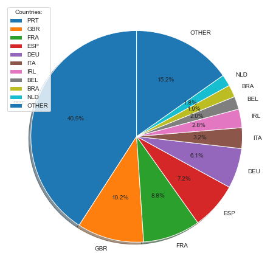

```python
countries_p = countries_p[:10]
countries_p = countries_p.append(pd.Series(100 - countries_p.sum(), index = ['OTHER']))

plt.figure(figsize = (8,8))
plt.pie(countries_p, labels = countries_p.keys(),  autopct='%1.1f%%',
        shadow=True, startangle=90)
plt.legend(title = "Countries:")
plt.show()
```

De los huéspedes que cancelan sus reservaciones el *62%* son de **Portugal**, y el resto de los países tienen porcentajes menor al *6%*.

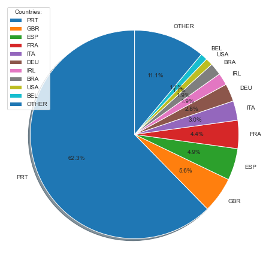

```python
countries_canceled =  data.groupby(['country'])['is_canceled'].sum()
countries_canceled_p = countries_canceled / countries_canceled.sum() *100
countries_canceled_p.sort_values(ascending=False, inplace = True)
countries_canceled_p = countries_canceled_p[:10]
countries_canceled_p = countries_canceled_p.append(pd.Series(100 - countries_canceled_p.sum(), index = ['OTHER']))

plt.figure(figsize = (8,8))
plt.pie(countries_canceled_p, labels = countries_canceled_p.keys(),  autopct='%1.1f%%',
        shadow=True, startangle=90)
plt.legend(title = "Countries:")
plt.show()
```

### ¿Cuánto pagan los huéspedes por una habitación por noche en promedio?

El precio promedio por noche de todos los datos que se tienen es de *$103.52*.

```python
data[data['adr']!=0]['adr'].mean()
```

```
103.52988222871303
```

### ¿Cómo varía el precio por noche durante el año?

En la gráfica se observa que en los 3 años que se tienen el precio promedio por noche aumenta en los meses antes del *verano* y baja pasando *Agosto*.

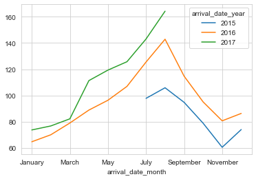

```python
new_order = ['January', 'February', 'March', 'April', 'May', 'June', 'July', 'August', 'September', 'October', 'November', 'December']
precio_year =  data.groupby(['arrival_date_month', 'arrival_date_year'])['adr'].mean().unstack()
precio_year = precio_year.reindex(new_order, axis=0).plot()
```

### ¿Cuáles son los meses más ocupados?

Los 3 meses más ocupados en el hotel son **Agosto** con el *11.62%* de las reservaciones, **Julio** con el *10.6%* y **Mayo** con el *9.88%*.

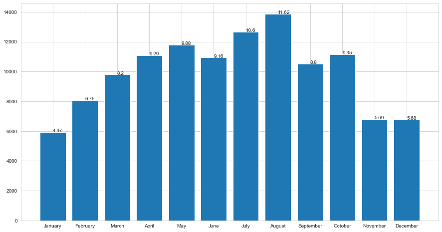

```python
months = data.arrival_date_month.value_counts()
months = months.reindex(new_order, axis=0)
months_p = np.round(months / months.sum() * 100,2)

plt.figure(figsize = (15,8))
plt.bar( months.keys(), months )

for i in range(0,len(months_p)):
    plt.text(i, months[i], str(months_p[i]))
plt.show()
```

### ¿Cuánto tiempo se queda la gente en los hoteles (noches)?

```python
nights = data.stays_in_weekend_nights + data.stays_in_week_nights
nights = nights.value_counts()
nights_p = nights/nights.sum()*100
nights_p
```

```
2     23.153530
3     22.678616
1     17.606165
4     14.559846
7      7.249351
5      6.519809
6      3.230589
8      0.972443
10     0.954016
14     0.767233
9      0.704414
0      0.598878
11     0.331686
12     0.186783
13     0.118938
```

[output cut: 31 more lines]

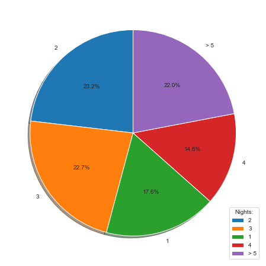

```python
nights_p = nights_p[:4]
nights_p = nights_p.append(pd.Series(100 - nights_p.sum(), index = ['> 5']))

plt.figure(figsize = (8,8))
plt.pie(nights_p, labels = nights_p.keys(),  autopct='%1.1f%%',
        shadow=True, startangle=90)
plt.legend(title = "Nights:")
plt.show()
```

### Reservas por segmento de mercado

Los 3 segmentos de mercado con mayor porcentaje de reservas son **Online TA** con el *47.3%*, **Offline TA/TO** con el *20.29%* y **Groups** con el *16.59%*.

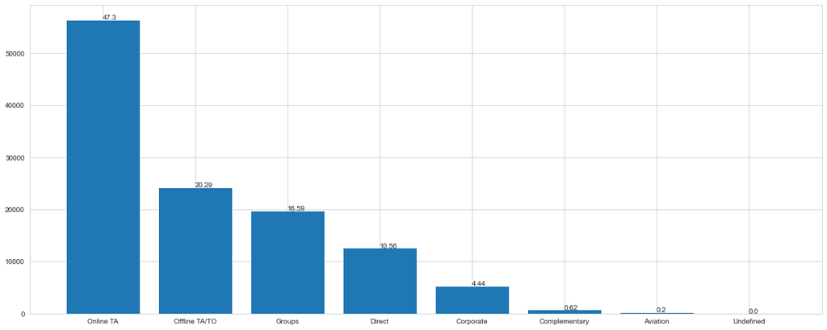

```python
market = data.market_segment.value_counts()
market_p = np.round(market / market.sum() * 100,2)

plt.figure(figsize = (20,8))
plt.bar( market.keys(), market )

for i in range(0,len(market)):
    plt.text(i, market[i], str(market_p[i]))
plt.show()
```

### ¿Cuántas reservas se cancelaron?

El *37%* de las reservaciones fueron canceladas. (44224)

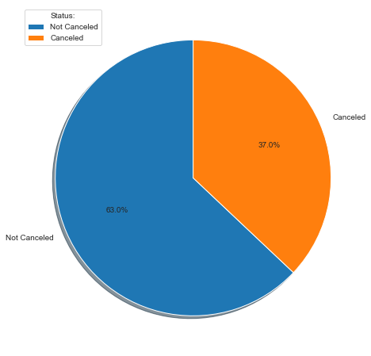

```python
canceled = data.is_canceled.value_counts()
canceled_p = canceled / canceled.sum() *100

plt.figure(figsize = (8,8))
plt.pie(canceled_p, labels = ['Not Canceled', 'Canceled'],  autopct='%1.1f%%',
        shadow=True, startangle=90)
plt.legend(title = "Status:")
plt.show()
```

### Qué mes tiene el mayor número de cancelaciones?

El mes con mayor número de cancelaciones es **Agosto** con el *11.85%* de las cancelaciones totales.

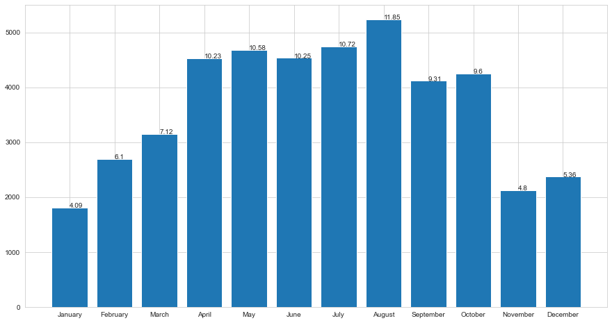

```python
canceled_month =  data.groupby(['arrival_date_month'])['is_canceled'].sum()
canceled_month = canceled_month.reindex(new_order, axis=0)
canceled_month_p = np.round(canceled_month / canceled_month.sum() * 100,2)

plt.figure(figsize = (15,8))
plt.bar( canceled_month.keys(), canceled_month )
#plt.bar( months.keys(), months )


for i in range(0,len(canceled_month)):
    plt.text(i, canceled_month[i], str(canceled_month_p[i]))
plt.show()
```

## Limpieza de datos

### Missing values

Primero reviso si hay valores faltantes y en que variables para ver si se pueden rellenar o se necesitan quitar. Faltan 4 datos en la columna 'children' que se rellenaran con 0 y 488 datos en la columna 'country' que se rellenaran con UNKNOWN. Faltan muchos datos en las columnas 'agent' y 'company' pero estas las considero no importantes y se quitarán. Además voy a quitar las columnas 'reservation_status', 'reservation_status_date' y 'arrival_date_year'.

```python
data.isnull().sum()
```

```
hotel                                  0
is_canceled                            0
lead_time                              0
arrival_date_year                      0
arrival_date_month                     0
arrival_date_week_number               0
arrival_date_day_of_month              0
stays_in_weekend_nights                0
stays_in_week_nights                   0
adults                                 0
children                               4
babies                                 0
meal                                   0
country                              488
market_segment                         0
distribution_channel                   0
is_repeated_guest                      0
previous_cancellations                 0
previous_bookings_not_canceled         0
reserved_room_type                     0
assigned_room_type                     0
booking_changes                        0
deposit_type                           0
agent                              16340
company                           112593
days_in_waiting_list                   0
customer_type                          0
adr                                    0
required_car_parking_spaces            0
total_of_special_requests              0
reservation_status                     0
reservation_status_date                0
dtype: int64
```

```python
new_data = data.drop(columns = ['agent', 'company', 'reservation_status', 'reservation_status_date', 'arrival_date_year'])
new_data.children.fillna(0, inplace = True)
new_data.country.fillna('UNKNOWN', inplace = True)

new_data.isnull().sum()
```

```
hotel                             0
is_canceled                       0
lead_time                         0
arrival_date_month                0
arrival_date_week_number          0
arrival_date_day_of_month         0
stays_in_weekend_nights           0
stays_in_week_nights              0
adults                            0
children                          0
babies                            0
meal                              0
country                           0
market_segment                    0
distribution_channel              0
is_repeated_guest                 0
previous_cancellations            0
previous_bookings_not_canceled    0
reserved_room_type                0
assigned_room_type                0
booking_changes                   0
deposit_type                      0
days_in_waiting_list              0
customer_type                     0
adr                               0
required_car_parking_spaces       0
total_of_special_requests         0
dtype: int64
```

### Outliers

#### IQR

Para quitar outliers intenté usando el IQR, pero como los datos no están distribuidos como una normal los límites que encuentro están muy bajos. Por ejemplo, para la columna children el límite superior es 0, sin embargo, los registros con 1 o 2 niños no son outliers.

```python
q25 = new_data.quantile(0.25)
q75 = new_data.quantile(0.75)
iqr = q75 - q25

# calculate the outlier cutoff
cut_off = iqr * 1.5
lower, upper = q25 - cut_off, q75 + cut_off
print(upper)
```

```
is_canceled                         2.500
lead_time                         373.000
arrival_date_week_number           71.000
arrival_date_day_of_month          45.500
stays_in_weekend_nights             5.000
stays_in_week_nights                6.000
adults                              2.000
children                            0.000
babies                              0.000
is_repeated_guest                   0.000
previous_cancellations              0.000
previous_bookings_not_canceled      0.000
booking_changes                     0.000
days_in_waiting_list                0.000
adr                               211.065
required_car_parking_spaces         0.000
total_of_special_requests           2.500
dtype: float64
```

#### Scatter Plots

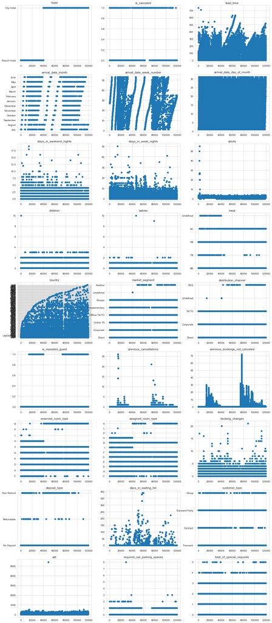

```python
cols = new_data.columns
plt.figure(figsize=(18,50))
columns = 3
for i, Xi in enumerate(cols):
    try:
        plt.subplot(int(len(cols) / columns + 1), columns, i + 1)
        plt.scatter(new_data.index, new_data[Xi])
        plt.gca().set_title(Xi)
        #plt.gca().set_title('{} upper IQR: {}'.format(Xi, upper[Xi]))
    except:
        print(Xi)
```

```python
new_data = new_data[new_data['lead_time']<700]
new_data = new_data[new_data['stays_in_week_nights']<40]
new_data = new_data[new_data['stays_in_weekend_nights']<15]
new_data = new_data[new_data['adults']<15]
new_data = new_data[new_data['children']<6]
new_data = new_data[new_data['babies']<6]
new_data = new_data[new_data['children']<6]
new_data = new_data[new_data['booking_changes']<20]
new_data = new_data[new_data['days_in_waiting_list']<300]
new_data = new_data[new_data['required_car_parking_spaces']<5]
new_data = new_data[new_data['adr']<1000]
```

Las graficas de abajo muestran los datos sin los outliers eliminados.

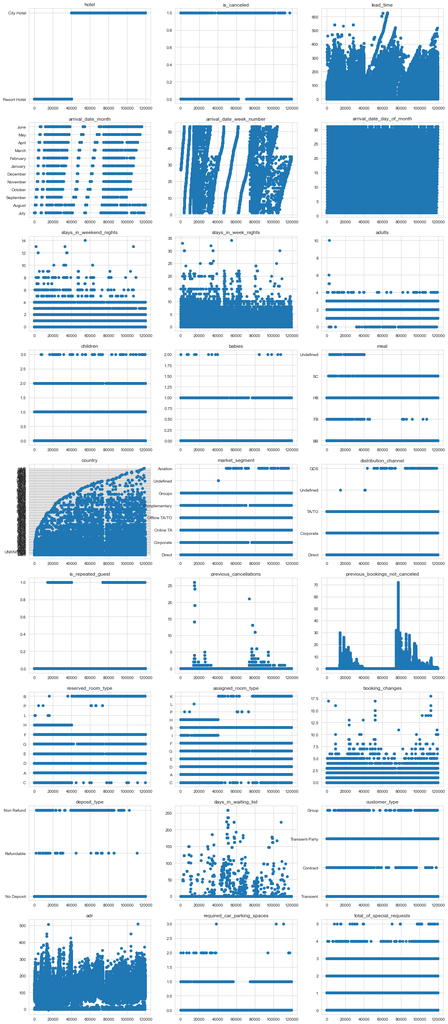

```python
cols = new_data.columns
plt.figure(figsize=(18,50))
columns = 3
for i, Xi in enumerate(cols):
    try:
        plt.subplot(int(len(cols) / columns + 1), columns, i + 1)
        plt.scatter(new_data.index, new_data[Xi])
        plt.gca().set_title(Xi)
        #plt.gca().set_title('{} upper IQR: {}'.format(Xi, upper[Xi]))
    except:
        print(Xi)
```

## Hacer tabla de correlación para las variables

Sólo se encuentra un poco de correlación entre las variables que miden la cantidad de noches que se quedan entre semana o en fin de semana, sin embargo no considero necesario tener que eliminar alguna de ellas.

```python
corr_df = new_data.corr(method='pearson')
corr_df.style.background_gradient(cmap='coolwarm')
```

|  | is_canceled | lead_time | arrival_date_week_number | arrival_date_day_of_month | stays_in_weekend_nights | stays_in_week_nights | adults | children | babies | is_repeated_guest | previous_cancellations | previous_bookings_not_canceled | booking_changes | days_in_waiting_list | adr | required_car_parking_spaces | total_of_special_requests |
| --- | --- | --- | --- | --- | --- | --- | --- | --- | --- | --- | --- | --- | --- | --- | --- | --- | --- |
| is_canceled | 1.000000 | 0.292588 | 0.007498 | -0.006209 | -0.001038 | 0.025624 | 0.063073 | 0.004924 | -0.034043 | -0.084690 | 0.110255 | -0.057319 | -0.145222 | 0.051583 | 0.049350 | -0.196788 | -0.234344 |
| lead_time | 0.292588 | 1.000000 | 0.125235 | 0.001642 | 0.087881 | 0.168150 | 0.128224 | -0.037155 | -0.021370 | -0.124473 | 0.086603 | -0.073611 | 0.000580 | 0.151579 | -0.063830 | -0.117225 | -0.094628 |
| arrival_date_week_number | 0.007498 | 0.125235 | 1.000000 | 0.066631 | 0.019340 | 0.016504 | 0.025536 | 0.005674 | 0.012146 | -0.029924 | 0.035585 | -0.020828 | 0.005820 | 0.011040 | 0.081148 | 0.002741 | 0.026591 |
| arrival_date_day_of_month | -0.006209 | 0.001642 | 0.066631 | 1.000000 | -0.015678 | -0.027728 | 0.001497 | 0.014723 | 0.000628 | -0.006132 | -0.027006 | -0.000282 | 0.011007 | 0.021295 | 0.030834 | 0.008755 | 0.003250 |
| stays_in_weekend_nights | -0.001038 | 0.087881 | 0.019340 | -0.015678 | 1.000000 | 0.490411 | 0.107854 | 0.045694 | 0.020303 | -0.087816 | -0.012823 | -0.043086 | 0.055843 | -0.049668 | 0.053725 | -0.018788 | 0.072106 |
| stays_in_week_nights | 0.025624 | 0.168150 | 0.016504 | -0.027728 | 0.490411 | 1.000000 | 0.110828 | 0.044286 | 0.023295 | -0.098249 | -0.014040 | -0.049360 | 0.087498 | 0.001973 | 0.071330 | -0.025379 | 0.067875 |
| adults | 0.063073 | 0.128224 | 0.025536 | 0.001497 | 0.107854 | 0.110828 | 1.000000 | 0.037621 | 0.025144 | -0.172250 | -0.007354 | -0.127225 | -0.057588 | -0.015440 | 0.298802 | 0.019030 | 0.149942 |
| children | 0.004924 | -0.037155 | 0.005674 | 0.014723 | 0.045694 | 0.044286 | 0.037621 | 1.000000 | 0.026743 | -0.032930 | -0.024795 | -0.021121 | 0.049175 | -0.035297 | 0.341890 | 0.057046 | 0.081747 |
| babies | -0.034043 | -0.021370 | 0.012146 | 0.000628 | 0.020303 | 0.023295 | 0.025144 | 0.026743 | 1.000000 | -0.009438 | -0.008005 | -0.006986 | 0.089834 | -0.012046 | 0.033896 | 0.041625 | 0.106864 |
| is_repeated_guest | -0.084690 | -0.124473 | -0.029924 | -0.006132 | -0.087816 | -0.098249 | -0.172250 | -0.032930 | -0.009438 | 1.000000 | 0.082309 | 0.418048 | 0.012229 | -0.023814 | -0.140959 | 0.074746 | 0.012987 |
| previous_cancellations | 0.110255 | 0.086603 | 0.035585 | -0.027006 | -0.012823 | -0.014040 | -0.007354 | -0.024795 | -0.008005 | 0.082309 | 1.000000 | 0.152726 | -0.027190 | 0.008650 | -0.068914 | -0.018623 | -0.048444 |
| previous_bookings_not_canceled | -0.057319 | -0.073611 | -0.020828 | -0.000282 | -0.043086 | -0.049360 | -0.127225 | -0.021121 | -0.006986 | 0.418048 | 0.152726 | 1.000000 | 0.011746 | -0.009755 | -0.075721 | 0.047380 | 0.037781 |
| booking_changes | -0.145222 | 0.000580 | 0.005820 | 0.011007 | 0.055843 | 0.087498 | -0.057588 | 0.049175 | 0.089834 | 0.012229 | -0.027190 | 0.011746 | 1.000000 | -0.011150 | 0.021082 | 0.066385 | 0.053360 |
| days_in_waiting_list | 0.051583 | 0.151579 | 0.011040 | 0.021295 | -0.049668 | 0.001973 | -0.015440 | -0.035297 | -0.012046 | -0.023814 | 0.008650 | -0.009755 | -0.011150 | 1.000000 | -0.039079 | -0.034636 | -0.088078 |
| adr | 0.049350 | -0.063830 | 0.081148 | 0.030834 | 0.053725 | 0.071330 | 0.298802 | 0.341890 | 0.033896 | -0.140959 | -0.068914 | -0.075721 | 0.021082 | -0.039079 | 1.000000 | 0.060505 | 0.181008 |
| required_car_parking_spaces | -0.196788 | -0.117225 | 0.002741 | 0.008755 | -0.018788 | -0.025379 | 0.019030 | 0.057046 | 0.041625 | 0.074746 | -0.018623 | 0.047380 | 0.066385 | -0.034636 | 0.060505 | 1.000000 | 0.083326 |
| total_of_special_requests | -0.234344 | -0.094628 | 0.026591 | 0.003250 | 0.072106 | 0.067875 | 0.149942 | 0.081747 | 0.106864 | 0.012987 | -0.048444 | 0.037781 | 0.053360 | -0.088078 | 0.181008 | 0.083326 | 1.000000 |

## Encontrar las mejores variables para predecir cancelaciones

```python
new_data.shape
```

```
(119288, 27)
```

```python
new_data.loc[new_data.country != 'PRT', 'country'] = 'OTRO'
```

```python
new_data['country']
```

```
id
1          PRT
3         OTRO
4         OTRO
5         OTRO
6         OTRO
          ...
119386    OTRO
119387    OTRO
119388    OTRO
119389    OTRO
119390    OTRO
Name: country, Length: 119288, dtype: object
```

```python
cols_categorical = ['hotel', 'arrival_date_month', 'meal', 'country', 'market_segment',
                    'distribution_channel', 'reserved_room_type', 'assigned_room_type', 'deposit_type',
                    'customer_type'  ]

encoded = new_data
for col in cols_categorical:
    encoded = pd.concat([encoded,pd.get_dummies(new_data[col], prefix=col)],axis=1)

encoded.drop(columns = cols_categorical, inplace=True)
encoded.shape
```

```
(119288, 80)
```

```python
Y = encoded['is_canceled']
X = encoded.loc[:, encoded.columns != 'is_canceled']

# normalizar los datos
scaler = MinMaxScaler()
X_scaled = scaler.fit_transform(X)
```

```python
# define the model
model = RandomForestClassifier()
# fit the model
model.fit(X_scaled, Y)
# get importance
importance = model.feature_importances_
imp = pd.DataFrame({'Feature':np.asarray(X.columns), 'importance':importance})
imp = imp.sort_values('importance', ascending = False)

imp.style.background_gradient(cmap='coolwarm')
```

|  | Feature | importance |
| --- | --- | --- |
| 0 | lead_time | 0.134850 |
| 13 | adr | 0.089558 |
| 72 | deposit_type_No Deposit | 0.066271 |
| 2 | arrival_date_day_of_month | 0.063154 |
| 73 | deposit_type_Non Refund | 0.056857 |
| 15 | total_of_special_requests | 0.056676 |
| 36 | country_PRT | 0.056520 |
| 1 | arrival_date_week_number | 0.051370 |
| 4 | stays_in_week_nights | 0.042505 |
| 9 | previous_cancellations | 0.028026 |
| 35 | country_OTRO | 0.027446 |
| 3 | stays_in_weekend_nights | 0.026954 |
| 43 | market_segment_Online TA | 0.022594 |
| 14 | required_car_parking_spaces | 0.020701 |
| 11 | booking_changes | 0.019248 |
| 77 | customer_type_Transient | 0.016800 |
| 42 | market_segment_Offline TA/TO | 0.014756 |
| 5 | adults | 0.013744 |
| 60 | assigned_room_type_A | 0.013185 |
| 78 | customer_type_Transient-Party | 0.012068 |
| 41 | market_segment_Groups | 0.011818 |
| 48 | distribution_channel_TA/TO | 0.010588 |
| 50 | reserved_room_type_A | 0.006979 |
| 63 | assigned_room_type_D | 0.006836 |
| 6 | children | 0.006670 |
| 30 | meal_BB | 0.006317 |
| 17 | hotel_Resort Hotel | 0.006262 |
| 16 | hotel_City Hotel | 0.006218 |
| 23 | arrival_date_month_July | 0.005315 |
| 19 | arrival_date_month_August | 0.005256 |
| 46 | distribution_channel_Direct | 0.005003 |
| 53 | reserved_room_type_D | 0.004709 |
| 32 | meal_HB | 0.004683 |
| 26 | arrival_date_month_May | 0.004573 |
| 10 | previous_bookings_not_canceled | 0.004444 |
| 24 | arrival_date_month_June | 0.004381 |
| 18 | arrival_date_month_April | 0.004149 |
| 40 | market_segment_Direct | 0.004117 |
| 29 | arrival_date_month_September | 0.004020 |
| 28 | arrival_date_month_October | 0.003976 |
| 33 | meal_SC | 0.003769 |
| 25 | arrival_date_month_March | 0.003625 |
| 21 | arrival_date_month_February | 0.003241 |
| 27 | arrival_date_month_November | 0.002839 |
| 20 | arrival_date_month_December | 0.002753 |
| 12 | days_in_waiting_list | 0.002697 |
| 64 | assigned_room_type_E | 0.002680 |
| 22 | arrival_date_month_January | 0.002487 |
| 8 | is_repeated_guest | 0.002458 |
| 45 | distribution_channel_Corporate | 0.002454 |
| 54 | reserved_room_type_E | 0.002157 |
| 75 | customer_type_Contract | 0.002131 |
| 65 | assigned_room_type_F | 0.001855 |
| 39 | market_segment_Corporate | 0.001827 |
| 61 | assigned_room_type_B | 0.001659 |
| 66 | assigned_room_type_G | 0.001365 |
| 62 | assigned_room_type_C | 0.001202 |
| 55 | reserved_room_type_F | 0.001173 |
| 56 | reserved_room_type_G | 0.001058 |
| 34 | meal_Undefined | 0.001032 |
| 51 | reserved_room_type_B | 0.000820 |
| 7 | babies | 0.000810 |
| 31 | meal_FB | 0.000659 |
| 52 | reserved_room_type_C | 0.000632 |
| 67 | assigned_room_type_H | 0.000400 |
| 57 | reserved_room_type_H | 0.000366 |
| 38 | market_segment_Complementary | 0.000365 |
| 68 | assigned_room_type_I | 0.000330 |
| 76 | customer_type_Group | 0.000303 |
| 47 | distribution_channel_GDS | 0.000256 |
| 69 | assigned_room_type_K | 0.000252 |
| 74 | deposit_type_Refundable | 0.000251 |
| 37 | market_segment_Aviation | 0.000210 |
| 71 | assigned_room_type_P | 0.000110 |
| 59 | reserved_room_type_P | 0.000101 |
| 49 | distribution_channel_Undefined | 0.000040 |
| 44 | market_segment_Undefined | 0.000017 |
| 58 | reserved_room_type_L | 0.000016 |
| 70 | assigned_room_type_L | 0.000005 |

```python
cols_drop = ['babies', 'is_repeated_guest', 'days_in_waiting_list', 'previous_bookings_not_canceled']
selected = X.drop(columns = cols_drop)
selected.shape
```

```
(119288, 75)
```

## Predecir a través de 3 diferentes modelos.

```python
Y = new_data['is_canceled']
X = selected

# normalizar los datos
scaler = MinMaxScaler()
X_scaled = scaler.fit_transform(X)
```

```python
# evaluate a logistic regression model using k-fold cross-validation
from sklearn.model_selection import KFold
from sklearn.model_selection import cross_val_score
from sklearn.linear_model import LogisticRegression, SGDClassifier
```

### Regresión Logística

```python
cv = KFold(n_splits=4, random_state=1, shuffle=True)
# create model
model = LogisticRegression()
# evaluate model
scores = cross_val_score(model, X_scaled, Y, scoring='accuracy', cv=cv, n_jobs=-1)
print(scores)
print('Accuracy: %.3f (%.3f)' % (np.mean(scores), np.std(scores)))
```

```
[0.8077929  0.80980484 0.80454027 0.80658574]
Accuracy: 0.807 (0.002)
```

### SGD Classifier

```python
cv = KFold(n_splits=4, random_state=1, shuffle=True)
# create model
clf = SGDClassifier(max_iter=1000, tol=1e-3)
# evaluate model
scores = cross_val_score(clf, X_scaled, Y, scoring='accuracy', cv=cv, n_jobs=-1)
print(scores)
print('Accuracy: %.3f (%.3f)' % (np.mean(scores), np.std(scores)))
```

```
[0.80782644 0.80138824 0.80430555 0.80279659]
Accuracy: 0.804 (0.002)
```

### Random Forest

```python
cv = KFold(n_splits=4, random_state=1, shuffle=True)
# create model
model3 = RandomForestClassifier()
# evaluate model
scores = cross_val_score(model3, X_scaled, Y, scoring='accuracy', cv=cv, n_jobs=-1)
print(scores)
print('Accuracy: %.3f (%.3f)' % (np.mean(scores), np.std(scores)))
```

```
[0.88568842 0.88578901 0.88371001 0.88267051]
Accuracy: 0.884 (0.001)
```

## ¿Cuál es el modelo con mayor performance?

De los modelos que se probaron el mejor es el **Random Forest**, en el cual se obtiene un score del *88.4%* en accuracy.